# Hunting As United States Pastime 1960 to 2020: Implications for Conservation

Robert Wiederstein

11/14/2020

# 1 Question

Hunting as a pastime is declining in the United States.[^1] Its prolonged slump and projected decline is significant because license fees and taxes fund wildlife conservation efforts. This “user-play, user-pay” funding system–a model replicated across the globe–is jeopardizing conservation efforts as hunting declines. (Rott 2018)Recent legislative proposal at the federal level have attempted to diversify funding sources in response. The question for consideration is whether hunting declined from 1960 to 2020, how much agreement exists between available data sources, and which states have been impacted.

# 2 Background

Hunting is a significant source of entertainment, excercise, camraderie, and nourishment for many Americans, especially those living in rural locations where leisure opportunities are scarce and wildlife more prevalent. Every five years the National Survey of Fishing, Hunting and Wildlife Associated Recreation is conducted by the U.S. Fish and Wildlife and the U.S. Census. The last survey in 2016 found that “11.5 million people 16 years and older enjoyed hunting a variety of animals within the United States. They hunted 184 million days and took 147 million trips. Hunting expenditures totaled $26.2 billion.” (US Census Bureau 2016) The survey reported that the national participation rate was four percent with significant regional variation. For example, the New England region had a two percent participation rate while the East South Central region had an eight percent participation rate. (US Census Bureau 2016) Given its popularity and economic impact, hunting is rightfully the subject of intense study.

## 2.1 Wildlife as Public Resource

Wildlife is a public resource and should be managed prudently. The Public Trust Doctrine (PTD) is considered to be the cornerstone of the North American Model of Wildlife Conservation (AMWC). The doctrine posits that “wildlife is owned by no one and held in trust by governments for the present and future benefit of its citizens.”(Jacobson et al. 2010) It was first recognized by the United States Supreme Court in the seminal case Martin vs. Waddell’s Lessee, 41 U.S. 367 (1842). There, the Court held “that the *public held a common right* to fish in navigable and tidal waters of New Jersey because they and their underlying lands *were owned by the state for the common use by the people*.” (The Wildlife Society et al. 2010)

While Martin v. Waddell’s Lessee may have been the first case, the more signifcant one in U.S. Supreme Court jurisprudence was Illinois Central Railroad v. Illinois, 146 U.S. 387 (1892). There, the Illinois Legislature had granted an portions of the waterfront and harbor to the Illinois Central Railroad. The conveyance was contested by a subsequent legilsature. The Court held that the public trust doctrine prevented the legislture from alienating the public right to the lands under navigable waters. (“Illinois Central Railroad V. Illinois” 1892) Professor James L. Sax refers to the case as the “lodestar” in American public trust law. (Sax 1970)

Since the government under American law is entrusted with the public’s assets, it has a responsiblity as trustee and fiduciary to safeguard them for the long term benefit of the public.(The Wildlife Society et al. 2010)

## 2.2 U.S. Conservation Movement

Many commentators date the modern U.S. Conservation movement with the establishment of the first national park. In 1872, a bill creating Yellowstone National Park was signed into law by President Ulysses S. Grant. American sportsmen were the catalyst for the U.S. conservation movement who saw the waste of wildlife and habitat as a cause for the extinction of some species and sought to preserve others.(Reiger 2000). Westward expansion of the railroad and the associated extinction of wildlife species catalyzed the American conservationists. The loss of the passenger pigeon 1916 and the near extirpation of the bison brought an urgency to preserve the environment.

Figure 2.1: Plot shows that a large portion of federal action occurred in the twenty years between 1900 and 1920. Data taken from the Library of Congress Evolution of the Conservation Movement [website.](http://memory.loc.gov/ammem/amrvhtml/conshome.html)

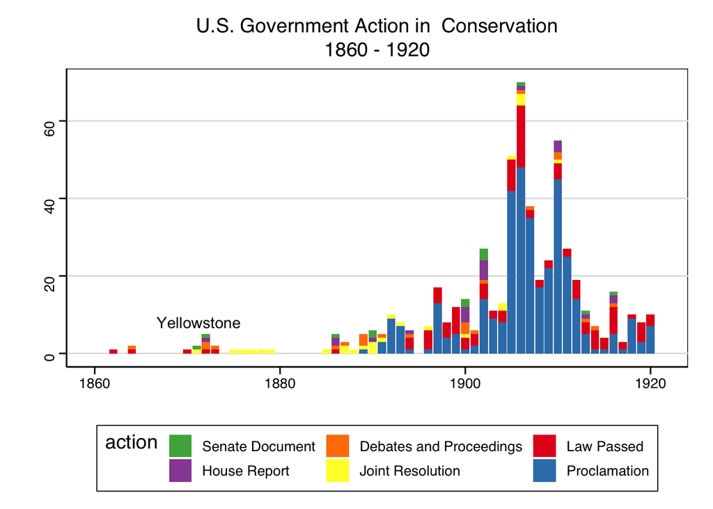

The subjects of the various federal actions included the acquisition of land to be set aside for national parks, the establishment of a national park service, irrigation of the arid lands of the West, the granting of railroad right-of-way through federal lands, the regulation of seal hunting and other fur bearing animals in the “District” of Alaska, the establishment of fish hatcheries, protection of trees on federal lands from the harvesting of pitch or turpentine, regulation of the sale and harvest of sponges from the Gulf of Mexico, the study of Texas oyster beds, the protection of migratory birds, and the creation of a commission on the construction and use of water power–among the many, many actions.

Several federal enactments would have lasting and profound impact on state conservation efforts. Speecifically, the creation of the U.S. Fish and Wildlife Service, the Pittman-Robertson Act and the Dingell-Johnson Act.

History of the U.S. Fish and Wildlife Service

Due to the success of the Pittman–Robertson Act, a similar act was proposed for the protection of fish species, titled his act was titled the Federal Aid in Sports Fish Restoration Act.

## 2.3 State Role in Conservation

Wildlife management is divided between the federal government and individual states. States have primary responsibility as the trustees of wildlife due to the Public Trust Doctrine, except where the Constitution provided for federal oversight.(Bean et al. 1997) “Regulated hunting and trapping have been cornerstones of wildlife management in the United States since the advent of wildlife conservation,” write two prominent zoologists along these lines."(Braverman 2015)

Table 2.1: State Fish & Wildlife Conservation Funding by Source

| source | type | pct |
| --- | --- | --- |
| Agency | License Sales | 35% |
| Agency | Entry Fee | 3% |
| Agency | Small Grants | 3% |
| Agency | Watercraft | 2% |
| Agency | Trust | 1% |
| Agency | OHV | 1% |
| Federal | Pittman-Robertson | 15% |
| Federal | Dingell-Johnson | 9% |
| Federal | USFWS | 4% |
| Federal | Coast Guard | 1% |
| State | General Fund | 8% |
| State | Non-General Fund | 6% |
| State | Sales Tax | 3% |
| Other | Other | 11% |

<sup>1</sup> Column does not total to 100% due to rounding errors.  
<sup>2</sup> Data from Assoc. of Fish and Wildlife Agencies, Survey.

The Association of Fish and Wildlife Agencies recently surveyed its members from all 50 states. The effort was undertaken to better understand the scope of state conservation efforts. Forty-six members participated. The agencies own, manage, leverage, spend or employ

- 464 million acres of land;
- 167 million acres of lakes, reservoirs, wetlands and riparian areas;
- 190,000 volunteers;
- 50,000 total employees;
- 11,000 degreed biologists;
- 10,100 law enforcement officers;
- 6,000 employees with advanced degrees;
- 43,515 vehicles; and
- 5.6 billion dollars in combined budgets

The survey cited as a “major problem” the fact that most citizens do not realize that conservation efforts are primarily shouldered by state fish and wildlife agencies. (Association of Fish & Wildlife Agencies 2017) The table 2.1 at right shows funding by source with hunter licensing fees and Pittman-Robertson funs being the two larges revenue sources.

## 2.4 Decline of Hunting

According to an article in Outdoor Life, hunting reached its peak in 1982 when nearly 17 million hunters purchased 28.3 million licenses. Additionally, persons born between the years 1946 and 1964, commonly referred to as the “Baby Boomers”, are the largest cohort of hunters and will age out of the sport in the next 15 years.(Krebs 2019) The decline was acknowledged and projected to continue in Wisconsin deer hunters through 2030. (Winkler and Warnke 2013)

In a 2012 study of Wisconsin deer hunters, researchers projected 10% decline through 2020 and an additional 18% decline from 2020 to 2030. (Winkler and Warnke 2013)

## 2.5 Reasons for Decline

Legal hunting enjoys widespread public support in spite of declining participation. The decline of hunting has less to do with overall public perception and more with changing preferences and demographics within American society. In a 2019 survey funded by the Association of Fish and Wildlife Agencies, legal hunting continues to enjoy widespread support with 80% of public supporting it. (Response Management and National Shooting Sports Foundation 2019) This level of approval has been stable since 1975 when it was first reported at 75%. The approval was greatest when hunting was undertaken for sustenance, safety or wildlife control, but dropped when the activity was undertaken for sport or to obtain trophies. (Response Management and National Shooting Sports Foundation 2019) Support was greatest when the respondent was “male, white, living in a rural area, living in the Midwest or Southeast regions, and growing up with firearms.”(Response Management and National Shooting Sports Foundation 2019)

Various explanations for the decline in hunting have been tendered. Researchers found evidence that more people opt for electronic entertainment and urban living as explanations for the decline in hunting. (Robison and Ridenour 2012a)

## 2.6 Declining Fees and Taxes

“Fish and wildlife conservation funding in the U.S., at least at the state level, typically is characterized as a user-pay, user-benefit model.” (Organ et al. 2012) “From the earliest days of active management and enforcement by nascent state fish and wildlife agencies, hunters, anglers, and trappers have funded restoration and conservation initiatives.”(Organ et al. 2012) Conservation efforts are generally financed through two sources: the sale of hunting licenses from the state and the sale of firearms. Though smaller resources also add to conservation efforts. To this day, the combination of sportsmen-derived funds from hunting licenses and gun sales comprise between 60 and 90 percent of the typical state fish and wildlife agency budget.(Organ et al. 2012) Some wildlife agencies’ budgets, however, rely on even higher percentages of revenue from sportsmen. States, like Texas, fund 97% of its conservation efforts from these two sources.(Braverman 2015)

The primary reliance on hunters as the funding mechanism for conservation is frustrating for many. “Hunters are key stakeholders; their contributions and integral role in wildlife conservation continue to be important. Maintaining hunter involvement and financial support of the Institution is necessary, but not sufficient.” (Jacobson et al. 2010) Jacobson further states that “[w]e can no longer rely on our most committed constituency to carry the brunt of the financial burden and subsequently be the primary beneficiaries of our actions.”(Jacobson et al. 2010)

Conservations efforts require long term, sustainable and dependable funding sources. (Jacobson et al. 2010) User-based funding is declining and benefits a narrow group of constituents. “Other funding options states have pursued include dedicated revenues from vehicle license plates, voluntary tax check-offs, and nonprofit foundations to accept financial gifts.”(Jacobson et al. 2010) These fees have been voluntary and negligible in their impact. Missouri and Virginia were cited as having funding models that were “reliable, consistent and broad-based.” (Jacobson et al. 2010)

### 2.6.1 Federal Taxes

The Pittman-Robertson act directed that funds collected from the sale of firearms be deposited into the Federal Aid to Wildlife Restoration Fund. - a 10 percent tax on pistols and revolvers(“26 USCS _ 4181.PDF,” n.d.); - an 11 percent tax on bows, archery equipment,and long arms; - an inflation adjusted tax on arrow shafts, standing at 48 cents per shaft in 2014;

“Congress requires each state and U.S. territory to develop a State Wildlife Action Plan - a proactive, comprehensive conservation strategy which examines species health and recommends actions to conserve wildlife and vital habitat before they become more rare and costly to protect.”(Alliance for America’s Fish & Wildlife, n.d.: 2)

“A national survey determined that each state needs an average of 26 million in new funding annually ($1.3 billion collectively) to e!ectively implement State Wildlife Action Plans to prevent species from becoming threatened or endangered.”(Alliance for America’s Fish & Wildlife, n.d.: 3)

“Current funding through State and Tribal Wildlife Grant Program funds only reaches a national total of 60 million on average, a shortfall of more than $1.2 billion annually.”(Alliance for America’s Fish & Wildlife, n.d.)

## 2.7 Recent Federal Developments

“The bipartisan Recovering America’s Wildlife Act establishes a 21st century funding model for the proactive conservation of fish and wildlife. The bill will redirect 1.3 billion in existing revenues to state fish and wildlife agencies to implement their science-driven wildlife action plans, and an additional $97.5 million to tribal wildlife managers to conserve species on tribal.”(Alliance for America’s Fish & Wildlife, n.d.)

States would be required to provide at least 25% in nonfederal matching funds. The source of match can be monetary or in-kind contributions originating from state or local governments or private entities such as conservation organizations, universities, businesses, private landowners, or volunteers." (Alliance for America’s Fish & Wildlife, n.d.: 3)

# 3 Data Sources

Data was retrieved from three sources: the U.S. Fish and Wildlife Agency, the U.S. Census Bureau and the National Survey of Fishing, Hunting, & Wildlife-Associated Recreation.

## 3.1 U.S. Fish and Wildlife

States require a hunting license for those harvesting game. People who engage in hunting within the boundaries of the state they reside in require a “resident” hunting license whereas those who travel to another state require a “non-resident” license. A proxy for the popularity of the pastime is the number of hunting licenses issued by the states. The U.S. Fish and Wildlife tracks the issuance of hunting, and fishing, licenses.(US Fish & Wildlife 2020) Data is available via their [website](https://www.fws.gov/wsfrprograms/Subpages/LicenseInfo/Hunting.htm). Hunting license information is collected annually from (1) state, (2) territory and (3) insular areas license certifications. The data is available for the years 1958 - 2020, though it is in a pdf format. Variables included:

1. Certified Paid Hunting License Holders–Defined as one individual regardless of the number of licenses purchased.
2. Resident licenses, tags, permits and stamps.
3. Non-resident licenses, tags, permits and stamps.
4. Total hunting licenses, tags, permits and stamps.
5. Gross cost to resident hunters.
6. Gross cost to non-resident hunters.
7. Total gross cost to hunters.

The early years in the dataset did not have values in each of the columns.(US Fish & Wildlife 2020)

## 3.2 IPUMS Population Data

According to their [website](https://www.nhgis.org/about), “the IPUMS National Historical Geographic Information System (NHGIS) provides free online access to summary statistics and GIS files for U.S. censuses and other nationwide surveys from 1790 through the present.” (Manson et al. 2020). The total population data by state was needed for the years studied so that a per capita computation could be made.(Manson et al. 2020) NHGIS is one of several IPUMS data integration projects located with the Minnesota Population Center at the Institute for Social Research & Data Innovation at the University of Minnesota. (Manson et al. 2020)

## 3.3 National Survey FHWAR

The interviews were held in two stages: one via telephone of 22,725 to determine who hunted in the household and the second stage was a more in-depth interview of a subset from those identified in first stage.The 2016 survey–the latest available, 3,931 anglers and hunters and 3,997 wildlife watchers were interviewed.(U.S. Department of the Interior et al. 2016) The report was explicit that the sample size was large enough for a national conclusion, but the state-level survey was conducted by a private contractor and the results were not included in the report. "The 2016 Survey’s questions and methodology were similar to those used in the surveys since 1991 and were comparable.(U.S. Department of the Interior et al. 2016)

In spite of the cautionary disclaimers regarding comparisons between the surveys after 1991 to the surveys before 1991, the surveys prior to 1991 are included in this report, although they are designated by a different color. Table 3.1 showing the numerators and denominators for the calculation of the participation rate is included below. Note how the age groups change over time and the all-time high for hunters was 1975 when hunters as young as 9 were included.

Table 3.1: Computation of FHWAR Participation Rate 1955 - 2016

| year | method | tot_hunters | age_group_hunters | tot_pop | age_group_pop | part_rate |
| --- | --- | --- | --- | --- | --- | --- |
| 1955 | A | 11,784,000 | hunters_12_&_over | 118,366,000 | pop_12_&_over | 9.96% |
| 1960 | A | 14,637,000 | hunters_12_&_over | 131,226,000 | pop_12_&_over | 11.15% |
| 1965 | A | 13,583,000 | hunters_12_&_over | 141,928,000 | pop_12_&_over | 9.57% |
| 1970 | A | 14,366,000 | hunters_12_&_over | 155,230,000 | pop_12_&_over | 9.25% |
| 1975 | B | 20,591,000 | hunters_09_&_over | 184,300,000 | pop_09_&_over | 11.17% |
| 1980 | C | 12,791,000 | hunters_16_&_over | 169,942,000 | pop_16_&_over | 7.53% |
| 1985 | C | 16,684,000 | hunters_16_&_over | 181,095,000 | pop_16_&_over | 9.21% |
| 1991 | C | 14,063,000 | hunters_16_&_over | 189,964,000 | pop_16_&_over | 7.4% |
| 1996 | C | 13,975,000 | hunters_16_&_over | 201,472,000 | pop_16_&_over | 6.94% |
| 2001 | C | 13,034,000 | hunters_16_&_over | 212,298,000 | pop_16_&_over | 6.14% |
| 2006 | C | 12,510,000 | hunters_16_&_over | 229,245,000 | pop_16_&_over | 5.46% |
| 2011 | C | 13,674,000 | hunters_16_&_over | 239,313,000 | pop_16_&_over | 5.71% |
| 2016 | C | 11,453,000 | hunters_16_&_over | 254,686,000 | pop_16_&_over | 4.5% |

# 4 Analysis

## 4.1 General

| fips | state | abb | year | key | value |
| --- | --- | --- | --- | --- | --- |
| 01 | Alabama | AL | 1960 | certified_paid_hunting_license_holders | 311,454 |
| 02 | Alaska | AK | 1960 | certified_paid_hunting_license_holders | 31,474 |
| 04 | Arizona | AZ | 1960 | certified_paid_hunting_license_holders | 105,640 |
| 05 | Arkansas | AR | 1960 | certified_paid_hunting_license_holders | 223,641 |
| 06 | California | CA | 1960 | certified_paid_hunting_license_holders | 610,882 |
| 08 | Colorado | CO | 1960 | certified_paid_hunting_license_holders | 241,301 |

The variables that were assembled into the dataframe are as follows:

Table 4.2: Variable Frequency by Year

|  | 1960 | 1970 | 1980 | 1990 | 2000 | 2010 | 2020 |
| --- | --- | --- | --- | --- | --- | --- | --- |
| certified_paid_hunting_license_holders | 50 | 50 | 50 | 50 | 50 | 50 | 50 |
| gross_cost_to_non-resident_hunters | 0 | 50 | 50 | 50 | 50 | 0 | 50 |
| gross_cost_to_resident_hunters | 0 | 50 | 50 | 50 | 50 | 0 | 50 |
| non-resident_hunting_licenses_tags_permits_stamps | 0 | 50 | 50 | 50 | 50 | 50 | 50 |
| per_capita_hunting_license | 50 | 50 | 50 | 50 | 50 | 50 | 50 |
| pop | 50 | 50 | 50 | 50 | 50 | 50 | 50 |
| resident_hunting_licenses_tags_permits_stamps | 0 | 50 | 50 | 50 | 50 | 50 | 50 |
| total_gross_cost_to_hunters | 0 | 50 | 50 | 50 | 50 | 50 | 50 |
| total_hunting_licenses_tags_permits_stamps | 0 | 50 | 50 | 50 | 50 | 50 | 50 |
| wr_apportionment_real_dollars | 50 | 50 | 50 | 50 | 50 | 50 | 50 |

## 4.2 National

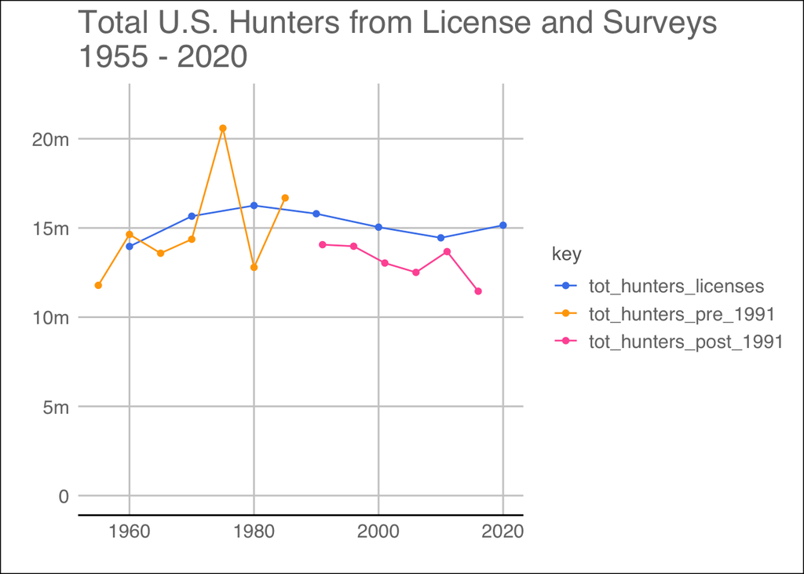

Figure 4.1: Figure shows the total number of hunting licenses or answering in the affirmative on the Survey of FHWAR. The blue line is from state submitted hunting license data. The pink and yellow series are from the Survey of FHWAR, but authors warn of using outcomes from the survey prior to 1991 because of a change in methodology

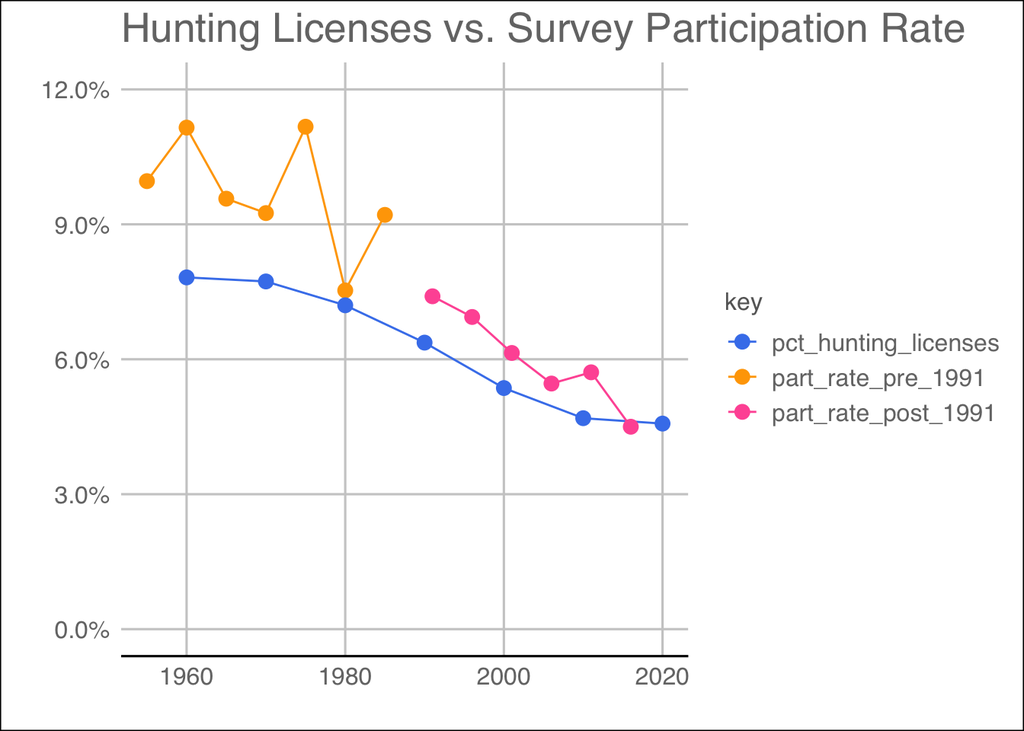

Figure 4.2: Figure shows the percentage of the population that engages in hunting. The blue line is from state submitted hunting license data. The pink and yellow series are from the Survey of FHWAR, but authors warn of using outcomes from the survey prior to 1991 because of a change in methodology

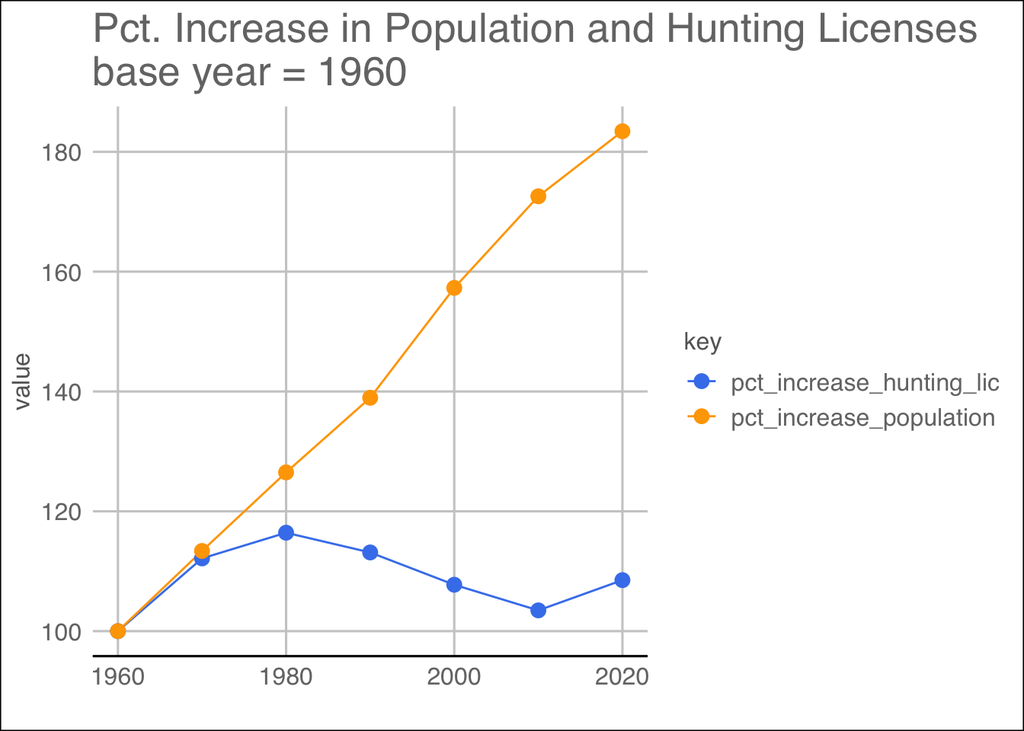

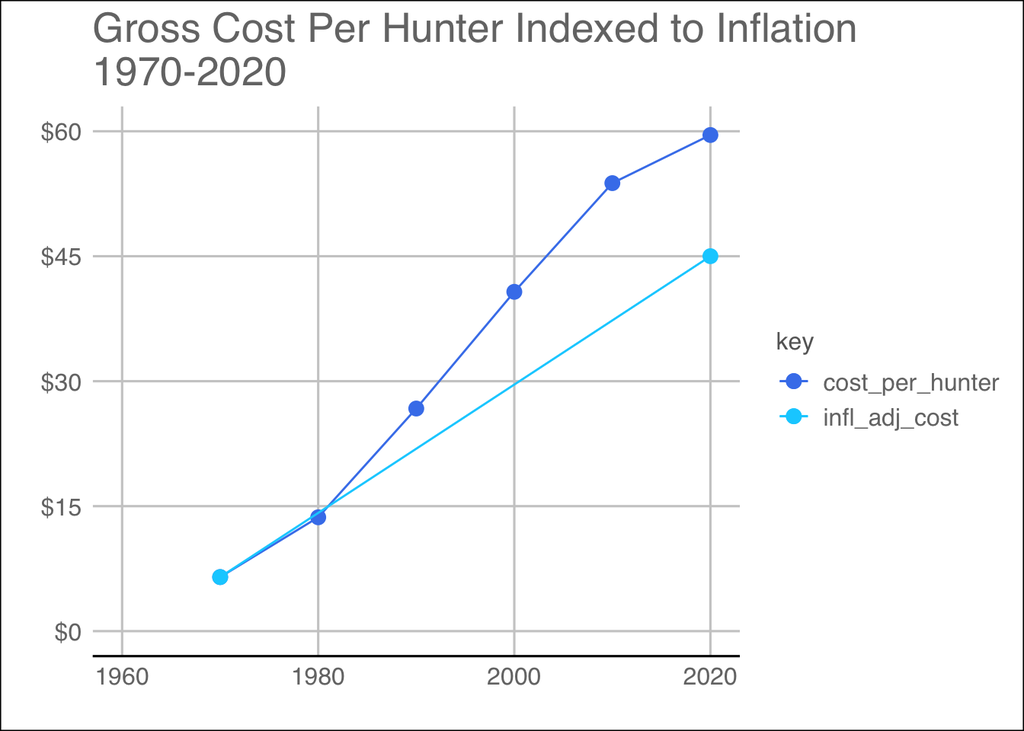

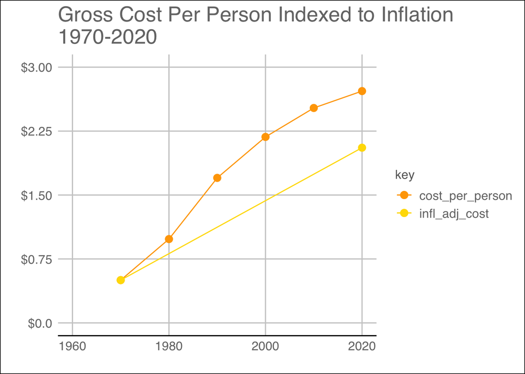

Figure 4.4: Gross cost per hunter and per person compared to inflation. Notice the y-axis showing that the per person cost is less than $3.00

| rank | state | licenses/1000 |
| --- | --- | --- |
| 1 | South Dakota | 239 |
| 2 | Wyoming | 224 |
| 3 | Montana | 209 |
| 4 | North Dakota | 166 |
| 5 | Idaho | 162 |
| 6 | Oklahoma | 140 |
| 7 | Alaska | 120 |
| 8 | West Virginia | 117 |
| 9 | Wisconsin | 117 |
| 10 | Maine | 115 |

| rank | state | licenses/1000 |
| --- | --- | --- |
| 41 | Nevada | 22 |
| 42 | Maryland | 19 |
| 43 | Delaware | 16 |
| 44 | Connecticut | 10 |
| 45 | Florida | 9 |
| 46 | Massachusetts | 8 |
| 47 | New Jersey | 8 |
| 48 | California | 7 |
| 49 | Hawaii | 7 |
| 50 | Rhode Island | 7 |

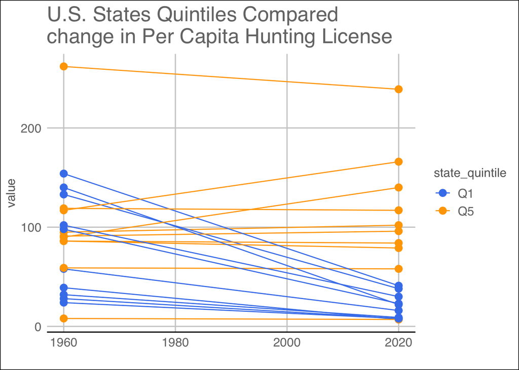

Table 4.3: Top 10 States %Change in Hunters

| rank | state | percent_change |
| --- | --- | --- |
| 1 | Oklahoma | 54.4% |
| 2 | North Dakota | 42.3% |
| 3 | Alabama | 7.5% |
| 4 | Mississippi | 6.1% |
| 5 | Georgia | -0.4% |
| 6 | West Virginia | -1.9% |
| 7 | Louisiana | -3% |
| 8 | Missouri | -8.7% |
| 9 | South Dakota | -9.1% |
| 10 | Hawaii | -12.7% |

Table 4.3: Bottom 10 States %Change in Hunters

| rank | state | percent_change |
| --- | --- | --- |
| 41 | Massachusetts | -65.7% |
| 42 | Virginia | -70.5% |
| 43 | Delaware | -71.3% |
| 44 | Indiana | -71.7% |
| 45 | New Jersey | -72% |
| 46 | New Hampshire | -73.1% |
| 47 | Florida | -73.2% |
| 48 | Washington | -76.9% |
| 49 | California | -83% |
| 50 | Nevada | -84% |

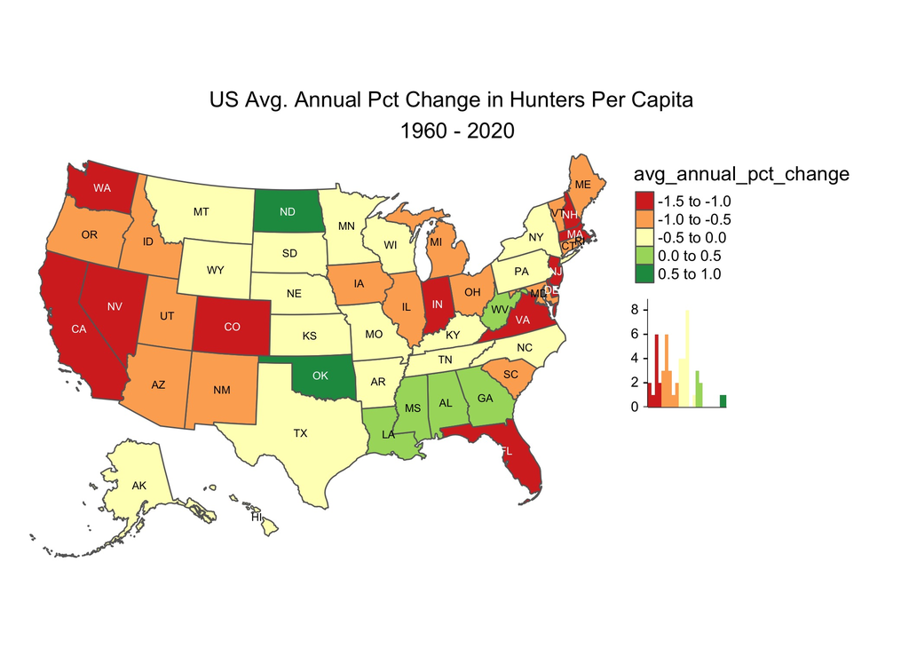

## 4.3 Further Research

2014 Allocation of gun revenue plotted compared to hunter license data. A floor and ceiling is set within the allocation forumula as well as territorial size.

# 5 Conclusions

# 6 Bibliography

“26 USCS _ 4161.PDF.” n.d.

“26 USCS _ 4181.PDF.” n.d.

Alliance for America’s Fish & Wildlife. n.d. “About Us - Alliance for America’s Fish & Wildlife.” http://ournatureusa.com/about-us/.

Andrew Loftus Consulting, and Southwick Associates, Inc. 2011. “Financial Returns to Industry from the Federal Aid in Wildlife Restoration Program.”

Archibald, Robert B., and David H. Feldman. 2006. “Graduation Rates and Accountability: Regressions Versus Production Frontiers.” Working Paper 24. Department of Economics, College of William and Mary.

Association of Fish & Wildlife Agencies. 2017. “The State Conservation Machine.” [n.p.].

———. n.d. “American System of Conservation Funding.” https://www.fishwildlife.org/afwa-informs/resources/american-system-conservation-funding.

———. n.d. “Annual Report 2019.”

Association of Fish & Wildlife Agencies and the Arizona Game and Fish Department. 2017. “The State Conservation Machine.”

Bean, Michael J., Melanie J. Rowland, Environmental Defense Fund, and World Wildlife Fund (U.S.). 1997. *The Evolution of National Wildlife Law*. Greenwood Publishing Group.

Bolen, Eric G., and William L. Robinson. 2002. *Wildlife Ecology and Management*. Fifth. Pearson.

Book. n.d.

Braverman, Irus. 2015. “Conservation and Hunting: Till Death Do They Part? A Legal Ethnography of Deer Management.” *Journal of Land Use & Environmental Law* 30 (2): 57.

Brown, Peter A. 2019. “Examining the Tragedy of the Commons Dilemma: Looking at the New Hampshire Fishing Industry.” Honors Theses and Capstones, University of New Hampshire.

Bureau of Sport Fisheries and Wildlife, and U.S. Fish and Wildlife Service. 1955. “1955 National Survey of Fishing and Hunting.” Washington, D.C.: U.S. Dept. of the Interior, Fish and Wildlife Service.

———. 1960. “1960 National Survey of Fishing and Hunting.” Washington, D.C.: U.S. Dept. of the Interior, Fish and Wildlife Service.

———. 1965. “1965 National Survey of Fishing and Hunting.” Washington, D.C.: U.S. Dept. of the Interior, Fish and Wildlife Service.

Bureau of the Census, and U.S. Fish and Wildlife Service. 1982. “1980 National Survey of Fishing, Hunting, and Wildlife-Associated Recreation.” Washington, D.C.: U.S. Department of the Interior, Fish and Wildlife Service.

Burkhauser, Richard, and Jeff Larrimore. 2008. “Using Internal Current Population Survey Data to Reevaluate Trends in Labor Earnings Gaps by Gender, Race, and Education Level.” Working Paper 08-18. Center for Economic Studies, U.S. Census Bureau.

Dizard, Jan E. 1994. *Going Wild: Hunting, Animal Rights, and the Contested Meaning of Nature*. Amherst: University of Massachusetts Press.

Enck, Jody W., Bryan L. Swift, and Daniel J. Decker. 1993. “Reasons for Decline in Duck Hunting: Insights from New York.” *Wildlife Society Bulletin (1973-2006)* 21 (1). [Wiley, Wildlife Society]: 10–21.

Floyd, Myron F., and Injae Lee. 2002. “Who Buys Fishing and Hunting Licenses in Texas? Results from a Statewide Household Survey.” *Human Dimensions of Wildlife* 7 (2). Routledge: 91–106. https://doi.org/10.1080/10871200290089364.

Goldin, Claudia. 1998. “America’s Graduation from High School: The Evolution and Spread of Secondary Schooling in the Twentieth Century.” *The Journal of Economic History* 58 (02): 345–74.

Goldin, Claudia, Ilyana Kuziemko, and Lawrence Katz. 2006. “The Homecoming of American College Women: The Reversal of the College Gender Gap.” Scholarly Articles 2962611. Harvard University Department of Economics.

goray. 2016. “About IPUMS NHGIS.” Text. *IPUMS NHGIS*. https://www.nhgis.org/about.

Graham, John W., Patricio E. Cumsille, and Allison E. Shevock. 2012. “Methods for Handling Missing Data.” In *Handbook of Psychology, Second Edition*. American Cancer Society. https://doi.org/10.1002/9781118133880.hop202004.

GUDE, JUSTIN A., JULIE A. CUNNINGHAM, JEFFREY T. HERBERT, and THOMAS BAUMEISTER. 2012. “Deer and Elk Hunter Recruitment, Retention, and Participation Trends in Montana.” *The Journal of Wildlife Management* 76 (3). [Wiley, Wildlife Society]: 471–79.

Gude, Justin A., Julie A. Cunningham, Jeffrey T. Herbert, and Thomas Baumeister. 2012. “Deer and Elk Hunter Recruitment, Retention, and Participation Trends in Montana.” *The Journal of Wildlife Management* 76 (3). [Wiley, Wildlife Society]: 471–79.

Heberlein, Thomas A. 2008. “Hunter Declines in US and Europe: Causes, Concerns, and Proposed Research.”

Heberlein, Thomas A., and Elizabeth Thomson. 1996. “Changes in U.S. Hunting Participation, 198090.” *Human Dimensions of Wildlife* 1 (1). Routledge: 85–86. https://doi.org/10.1080/10871209609359055.

———. 1997. “The Effects of Hunter-Education Requirements on Hunting Participation and Recruitment in the United States.” *Human Dimensions of Wildlife* 2 (1). Routledge: 19–31. https://doi.org/10.1080/10871209709359084.

Heckman, James J., and Paul A. LaFontaine. 2007a. “The American High School Graduation Rate: Trends and Levels.” IZA Discussion Paper 3216. Institute for the Study of Labor (IZA).

———. 2007b. “The American High School Graduation Rate: Trends and Levels.” Working Paper 13670. National Bureau of Economic Research.

Heckman, James J, and Paul A LaFontaine. 2010. “The American High School Graduation Rate: Trends and Levels.” *Review of Economics and Statistics* 92 (2): 244–62. https://doi.org/10.1162/rest.2010.12366.

Heffelfinger, James R., Valerius Geist, and William Wishart. 2013. “The Role of Hunting in North American Wildlife Conservation.” *International Journal of Environmental Studies* 70 (3). Routledge: 399–413. https://doi.org/10.1080/00207233.2013.800383.

Hernandez, Donald J. 2011a. “Double Jeopardy: How Third-Grade Reading Skills and Poverty Influence High School Graduation.” *Annie E. Casey Foundation*, April.

———. 2011b. “Double Jeopardy: How Third-Grade Reading Skills and Poverty Influence High School Graduation.” *Annie E. Casey Foundation*, April.

Hornaday, William T. (William Temple). 2006. *The Extermination of the American Bison*. Project Gutenberg.

“Illinois Central Railroad V. Illinois.” 1892.

Jacob, Brian A. 2002. “Where the Boys Aren’t: Non-Cognitive Skills, Returns to School and the Gender Gap in Higher Education.” NBER Working Paper 8964. National Bureau of Economic Research, Inc.

Jacobson, Cynthia, John Organ, Gordon Batcheller, and Len Carpenter. 2010. “A Conservation Institution for the 21st Century: Implications for State Wildlife Agencies.” *The Journal of Wildlife Management* 74 (December): 203–9. https://doi.org/10.2193/2008-485.

Krebs, Natalie. 2019. “Why We Suck at Recruiting New Hunters, Why It Matters, and How You Can Fix It.” *Outdoor LIfe*, October.

Li, Chieh-Lu, Harry C. Zinn, Susan C. Barro, and Michael J. Manfredo. 2003. “A Cross-Regional Comparison of Recreation Patterns of Older Hunters.” *Leisure Sciences* 25 (1). Routledge: 1–16. https://doi.org/10.1080/01490400306559.

Manning, Robert E. n.d. *Project MUSE - Studies in Outdoor Recreation*. 3rd ed. Corvallis: Oregon State University Press.

Manson, Steven, Jonathan Schroeder, David Van Riper, Tracy Kugler, and Steven Ruggles. 2020. “IPUMS National Historical Geographic Information System: Version 15.0 [Dataset].” Minneapolis, MN: IPUMS.

McCormick, Lacey. 2018. “One-Third of American Wildlife at Increased Risk of Extinction.” *National Wildlife Federation*. https://www.nwf.org/Home/Latest-News/Press-Releases/2018/03-29-18-Wildlife-Crisis-Report.

Mehmood, Sayeed, Daowei Zhang, and James Armstrong. 2003a. “Factors Associated with Declining Hunting License Sales in Alabama.” *Human Dimensions of Wildlife* 8 (4). Routledge: 243–62. https://doi.org/10.1080/716100423.

———. 2003b. “Factors Associated with Declining Hunting License Sales in Alabama.” *Human Dimensions of Wildlife* 8 (4). Routledge: 243–62. https://doi.org/10.1080/716100423.

Murnane, Richard J. 2013. “U.S High School Graduation Rates: Patterns and Explanations.” Working Paper 18701. National Bureau of Economic Research.

National Analysts, Inc., and U.S. Fish & Wildlife. 1977. *1975 National Survey of Hunting, Fishing and Wildlife-Associated Recreation :Conducted for U.S. Department of Interior, Fish and Wildlife Service /*. Philadelphia :

Organ, J.F., Valerius Geist, Shane P. Mahoney, Steven Williams, Paul R. Krausman, Gordon R. Batcheller, Thomas A. Decker, et al. 2012. “The Wildlife Society Technical Review 12-04.” The Wildlife Society: Bethesda.

“Organic Act.” 1912.

Poudyal, Neelam, Seong Hoon Cho, and J. M. Bowker. 2008a. “Demand for Resident Hunting in the Southeastern United States.” *Human Dimensions of Wildlife* 13 (3). Routledge: 158–74. https://doi.org/10.1080/10871200801922965.

———. 2008b. “Demand for Resident Hunting in the Southeastern United States.” *Human Dimensions of Wildlife* 13 (3). Routledge: 158–74. https://doi.org/10.1080/10871200801922965.

Reiger, John F. 2000. *American Sportsmen and the Origins of Conservation, 3rd Ed*. 3rd Revised and Expanded ed. edition. Corvallis: Oregon State University Press.

Response Management, and National Shooting Sports Foundation. 2019. “American’s Attitudes Toward Hunting, Fishing, Sport Shooting and Trapping.”

Robison, Kristopher K., and Daniel Ridenour. 2012a. “Whither the Love of Hunting? Explaining the Decline of a Major Form of Rural Recreation as a Consequence of the Rise of Virtual Entertainment and Urbanism.” *Human Dimensions of Wildlife* 17 (6). Routledge: 418–36. https://doi.org/10.1080/10871209.2012.680174.

———. 2012b. “Whither the Love of Hunting? Explaining the Decline of a Major Form of Rural Recreation as a Consequence of the Rise of Virtual Entertainment and Urbanism.” *Human Dimensions of Wildlife* 17 (6). Routledge: 418–36. https://doi.org/10.1080/10871209.2012.680174.

Rockville Institute. 2018. “50-State Survey of Fishing, Hunting and Wildlife-Related Recreation.” Oklahoma.

Rott, Nathan. 2018. “Decline in Hunters Threatens How U.S. Pays for Conservation.” *NPR.org*. https://www.npr.org/2018/03/20/593001800/decline-in-hunters-threatens-how-u-s-pays-for-conservation.

“R: The R Project for Statistical Computing.” 2020. Vienna Austria: R Foundation for Statistical Computing.

Rubio-Cisneros, Nadia T., Octavio Aburto-Oropeza, Jason Murray, Charlotte E. Gonzalez-Abraham, Jeremy Jackson, and Exequiel Ezcurra. 2014. “Transnational Ecosystem Services: The Potential of Habitat Conservation for Waterfowl Through Recreational Hunting Activities.” *Human Dimensions of Wildlife* 19 (1). Routledge: 1–16. https://doi.org/10.1080/10871209.2013.819536.

Sax, Joseph L. 1970. “The Public Trust Doctrine in Natural Resource Law: Effective Judicial Intervention.” *Michigan Law Review* 68 (3). The Michigan Law Review Association: 471–566. https://doi.org/10.2307/1287556.

SCHORR, ROBERT A., PAUL M. LUKACS, and JUSTIN A. GUDE. 2014. “The Montana Deer and Elk Hunting Population: The Importance of Cohort Group, License Price, and Population Demographics on Hunter Retention, Recruitment, and Population Change.” *The Journal of Wildlife Management* 78 (5). Wiley: 944–52.

Scrogin, David O., and Robert P. Berrens. 1999. “Determinants of Lottery Participation for Big Game Hunting Privileges: Resident Versus Nonresident Elk Hunters in New Mexico.” *Human Dimensions of Wildlife* 4 (1). Routledge: 36–49. https://doi.org/10.1080/10871209909359143.

Sellers, Frances Stead. 2020. “Hunting Is ‘Slowly Dying Off,’ and That Has Created a Crisis for the Nation’s Many Endangered Species.” *Washington Post*, February.

Southwick Associates. 2018. “Hunting in America: An Economic Force for Conservation.”

Tack, Jennifer L. Price, Conor P. McGowan, Stephen S. Ditchkoff, Wayde C. Morse, and Orin J. Robinson. 2018. “Managing the Vanishing North American Hunter: A Novel Framework to Address Declines in Hunters and Hunter-Generated Conservation Funds.” *Human Dimensions of Wildlife* 23 (6). Routledge: 515–32. https://doi.org/10.1080/10871209.2018.1499155.

Teisl, Dr Mario F., Dr Kevin J. Boyle, and Richard E. Record Jr. 1999. “License-Sales Revenues: Understanding Angler and Hunter Reactions to Changes in License Prices.” *Human Dimensions of Wildlife* 4 (4). Routledge: 1–17. https://doi.org/10.1080/10871209909359162.

The Wildlife Society, Association of Fish and Wildlife Agencies, Western Association of Fish and Wildlife Agencies, and Wildlife Management Institute. 2010. “The Public Trust Doctrine.” Wildlife Society: Maryland.

United States. 1972. *National Survey of Fishing and Hunting, 1970.* ItsResource Publication ;95. Washington, D.C.: U.S. Govt. Print. Office.

“[USC02] 31 USC 718: Availability of Draft Reports.” 1982.

US Census Bureau. 1991. “1991 FHWAR National and State Reports.” *The United States Census Bureau*. https://www.census.gov/library/publications/1993/demo/fhw-91-nat.html.

———. 1996. “1996 FHWAR National and State Reports.” *The United States Census Bureau*. https://www.census.gov/library/publications/1997/demo/fhw-96-nat.html.

———. 2001. “2001 FHWAR National and State Reports.” *The United States Census Bureau*. https://www.census.gov/library/publications/2002/demo/fhw-01-nat.html.

———. 2006. “2006 FHWAR National and State Reports.” *The United States Census Bureau*. https://www.census.gov/library/publications/2006/demo/fhw-06-nat.html.

———. 2011. “2011 FHWAR National and State Reports.” *The United States Census Bureau*. https://www.census.gov/library/publications/2014/demo/fhw-11-nat.html.

———. 2016. “2016 FHWAR National and State Reports.” *The United States Census Bureau*. https://www.census.gov/library/publications/2018/demo/fhw-16-nat.html.

U.S. Department of the Interior, and Fish and Wildlife Service. 1988. “1985 National Survey of Fishing, Hunting, and Wildlife Associated Recreation.”

U.S. Department of the Interior, U.S. Fish and Wildlife Service, U.S. Department of Commerce, and U.S. Census Bureau. 2016. “2016 National Survey of Fishing, Hunting, and Wildlife-Associated Recreation.”

“U.S. Education Reform and National Security.” n.d. *Council on Foreign Relations*. http://www.cfr.org/united-states/us-education-reform-national-security/p27618.

US Fish & Wildlife. 2020. “US Fish and Wildlife Service National Hunting License [Dataset].” Washington, D.C.: US Fish & Wildlife.

“Vermont Statutes Title 10. Conservation and Development, 4256.” n.d. *Findlaw*. https://codes.findlaw.com/vt/title-10-conservation-and-development/vt-st-tit-10-sect-4256.html.

Wickham, Hadley. 2014. “Tidy Data.” *Journal of Statistical Software* 59 (1): 1–23. https://doi.org/10.18637/jss.v059.i10.

———. 2016. “Ggplot2: Elegant Graphics for Data Analysis.”

Wickham, Hadley, and Lionel Henry. 2020. “Tidyr: Tidy Messy Data.”

Winkler, Richelle, and Keith Warnke. 2013. “The Future of Hunting: An Age-Period-Cohort Analysis of Deer Hunter Decline.” *Population and Environment* 34 (4): 460–80. https://doi.org/10.1007/s11111-012-0172-6.

Zhang, Xiaohan, and Craig A. Miller. 2019. “Associations Between Socioeconomic Status and Hunting License Sales Among Census Tracts in Cook County, Illinois.” *Human Dimensions of Wildlife* 24 (2). Routledge: 148–58. https://doi.org/10.1080/10871209.2018.1558466.

n.d.

# 7 Appendix

## 7.1 Annual Wildlife Restoration Apportionment

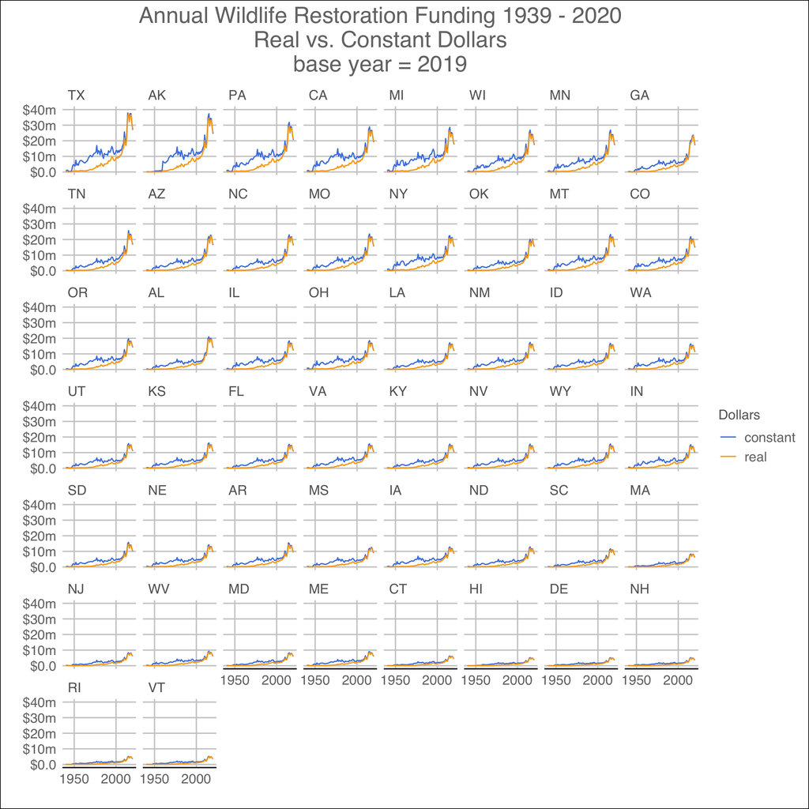

## 7.2 Directory of Fish & Wildlife Associations

[Directory of state F&W offices](https://www.fws.gov/info/pocketguide/sfwacontacts.html) [State and Territorial Fish and Wildlife Offices](https://www.fws.gov/offices/statelinks.html)

## 7.3 Federal Action in Conservation 1850 - 1920

The Library of Congress compiled a wide ranging collection of materials documenting the conservation movement. The collection, entitled “The Evolution of the Conservation Era 1850 to 1920”, can be found on its [website](http://memory.loc.gov/ammem/amrvhtml/conshome.html). The Law Library of the Library of Congress contributed 555 separate documents for the collection. Those materials are referenced here and serve as the basis for both the plot and the table below.

| date | cite | action | summary |
| --- | --- | --- | --- |
| 1900-03-06 | Acquisition of Certain Lands in California. Senate Report No. 533. From U.S. Senate Reports. 56th Congress. 1st Session. 1899-1900. | Senate Report | Report from the Committee on Public Lands, recommending passage of a resolution (S.R. 90) providing for the acquisition of lands in California containing Sequoia groves, with amendment; and quoting a … |
| 1906-01-01 | American Antiquities Act: Debates and Proceedings. Excerpted from the Congressional Record: Containing the Proceedings and Debates of the Fifty-Ninth Congress, First Session, also Special Session of t… | Debates and Proceedings | Procedure and debate surrounding the passage of S. 4698, which became An Act For the preservation of American antiquities (34 Stat. 225), known as the American Antiquities Act, in the First Session of… |
| 1907-01-01 | Appropriations Act Forbidding Further National Forests: Debates and Proceedings. Excerpted from the Congressional Record: Containing the Proceedings and Debates of the Fifty-Ninth Congress, Second Ses… | Debates and Proceedings | Procedure and debate surrounding the passage of H.R. 24815, which eventually became An Act Making appropriations for the Department of Agriculture for the fiscal year ending June thirtieth, nineteen h… |
| 1900-01-01 | California Big Tree Acquisition Resolution: Debates and Proceedings. Excerpted from the Congressional Record: Containing the Proceedings and Debates of the Fifty-Sixth Congress, First Session. Volume … | Debates and Proceedings | Procedure and debate surrounding the passage of H.J.R. 170, which became the Joint Resolution Providing for the acquisition of certain lands in the State of California (31 Stat. 711), in the First Ses… |
| 1889-01-01 | California Forest Reservations and Parks Act: Debates and Proceedings. Excerpted from the Congressional Record: Containing the Proceedings and Debates of the Fifty-First Congress, First Session. Also … | Debates and Proceedings | Procedure and debate surrounding the passage of H.R. 12187, which eventually became An act to set apart certain tracts of land in the State of California as forest reservations (26 Stat. 650), in the … |
| 1889-01-01 | California Public Park Lands Act: Debates and Proceedings. Excerpted from the Congressional Record: Containing the Proceedings and Debates of the Fifty-First Congress, First Session. Also Special Sess… | Debates and Proceedings | Procedure and debate surrounding the passage of H.R. 11570, which eventually became An act to set apart a certain tract of land in the State of California as a public park (26 Stat. 478), in the First… |
| 1900-02-26 | Certain Groves of Big Trees in California. House Report No. 436. From U.S. House Reports. 56th Congress. 1st Session. 1899-1900. | House Report | Report from the Committee on the Public Lands, to accompany H.J.R. 170, recommending passage of this resolution providing for the acquisition of lands in California containing Sequoia groves, with ame… |
| 1890-01-21 | Destruction of Forests of the United States. Senate Miscellaneous Document No. 51. Memorial of Albert Borcherdt of Denver, Colo. in The Miscellaneous Documents of the Senate of the United States for t… | Senate Miscellaneous Document | Letter from a citizen urging more active forest protection, and requesting Congress to furnish him with a tract of despoiled forest land so that he may use it for teaching in the academy of forestry w… |
| 1910-06-16 | Dumping of Refuse Material in Lake Michigan at or near Chicago. House Report No. 1613. From Reports of Committees of the House of Representatives for the Second Session of the Sixty-First Congress. 19… | House Report | Conference Report from the committee of conference to accompany H.R. 18700. |
| 1872-04-02 | Encouragement of the growth of timber on western prairies. Senate Miscellaneous Document No. 120. Letter from the Commissioner of the General Land-Office, Addressed to Honorable P.W. Hitchcock in The … | Senate Miscellaneous Document | Letter from the Commissioner of the General Land-Office in support of legislation to encourage timber cultivation on Western prairies, to accompany bill S. 680. |

[output cut: 545 more lines]

Figure 7.1: Table of U.S. Legislative and Executive Branch Actions in conservation from 1850 to 1920.

[^1]: The views, analysis and conclusions presented within this paper represent the author’s alone and not of any other person, organization or government entity. While I have made every reasonable effort to ensure that the information in this article was correct, it will nonetheless contain errors, inaccuracies and inconsistencies. It is a working paper subject to revision without notice as additional information becomes available. Any liability is disclaimd as to any party for any loss, damage, or disruption caused by errors or omissions, whether such errors or omissions result from negligence, accident, or any other cause. The author(s) received no financial support for the research, authorship, and/or publication of this article.